# **Wine Quality Exploration by Ricardo Yoshitomi**

# Bivariate Analysis

### Talk about some of the relationships you observed in this part of the investigation. How did the feature(s) of interest vary with other features in the dataset?

I was most interested to know how the wine’s quality varies with the physicochemical variables and I found some interesting relationships. Quality is moderately correlated with alcohol, sulphates, citric acid and volatile acidity. Although quality doesn’t have a strong correlation with any physicochemical variable, when plotting these variables with quality, which is a categorical variable, we can analyse each quality separately and better understand how these variables affect the wine’s quality.

The variable which has the strongest correlation with quality is alcohol. The Pearson correlation coefficient is 0.476. The plot of quality versus alcohol shows from the quality 3 to 5 there is no significant change when the quality improves. But from the quality 6 to 8 as the median of alcohol for each quality increases, the quality improves.

Quality is negatively correlated with volatile acidity. The correlation coefficient is -0.391. According to the plot, as the median of volatile acidity for each quality decreases, the wine’s quality improves.

Quality also correlates with citric acid. They are positively correlated and the correlation coefficient is 0.226. As the median of citric acid for each quality gradually increases, the quality increases.

Lastly, quality and sulphates are also positively correlated. The correlation coefficient is 0.251. Later we will see how the sulphates can affect other variables and consequently the quality.

### Did you observe any interesting relationships between the other features (not the main feature(s) of interest)?

Residual sugar and alcohol are moderately correlated with density as described by the author. I didnt’t expect to find a correlation between density and fixed acidity.

### What was the strongest relationship you found?

The strongest correlation I found is the pH with fixed acidity (Pearson’s coefficient = -0.683). The fixed acidity is also positively and strongly correlated with citric acid and density.

# Multivariate Plots Section

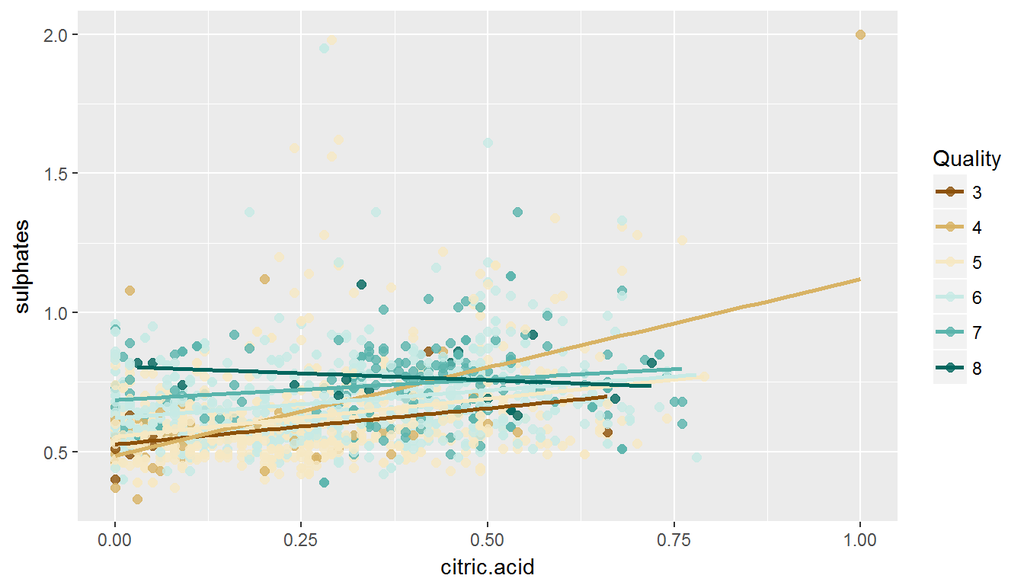

Potassium metabisulfite (sulphate) is a common wine or must additive, in which it forms sulfur dioxide gas (SO2). This both prevents most wild microorganisms from growing, and it acts as a potent antioxidant, protecting both the color and delicate flavors of wine (Source: https://en.wikipedia.org/wiki/Potassium_metabisulfite#Wine).

The sulphate is commonly added when grapes arrive at the winery. The purpose is to prevent oxidation and sometimes to delay the onset of fermentation (Source: https://en.wikipedia.org/wiki/Red_wine). The addition of high quantities of sulphates leads to a better conserved grapes.

Citric acid is found only in very minute quantities in wine grapes (Source: https://en.wikipedia.org/wiki/Acids_in_wine). Although citric acid is found in low quantities in wine grapes, even a small increment due to the conservation of grapes can improve wine’s flavor.

We can see on the previous plot that sulphates is moderately correlated with citric acid (Pearson’s coefficient = 0.313). It means that sulphates have an important role in the conservation of grapes that indirectly will lead to a higher amount of citric acid. The higher the quantity of citric acid, the better is the wine’s quality.

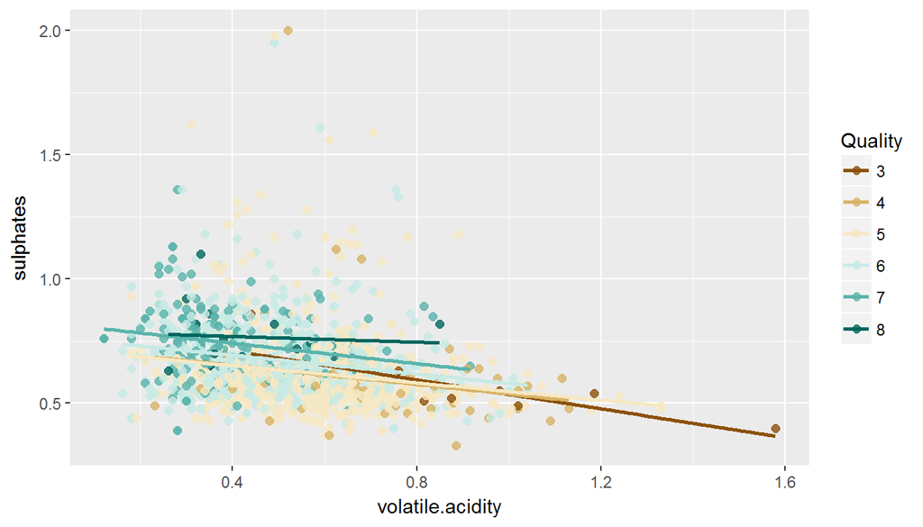

Among other benefits to the wine, the addition of sulphates can also decrease of the amount of volatile acidity. If the wine is exposed to oxygen, *Acetobacter* bacteria will convert the ethanol into acetic acid (Source: https://en.wikipedia.org/wiki/Acids_in_wine#Other_acids). As the sulphates prevent the wine being in contact with oxygen, the production of acetic acid will decrease.

Sulphates and volatile acidity are moderately correlated (Pearson’s coefficient = -0.261). But this relationship is sufficient to change the wine’s quality. We can see on the plot that higher quantities of sulphates decrease the amount of volatile acidity and consequently improves the quality.

# Multivariate Analysis

### Talk about some of the relationships you observed in this part of the investigation. Were there features that strengthened each other in terms of looking at your feature(s) of interest?

Yes, sulphates have an important role on the conservation of wine grapes. As citric acid is found in wine grapes, the addition of sulphates can increase the amount of citric acid and also decreases the volatile acidity quantity because sulphates prevents the wine from oxidation. These both variables interfere on the wine’s quality.

The two plots of this section use linear models to understand how the relationship between two variables could affect another important feature, in this case the quality.

### Were there any interesting or surprising interactions between features?

Sulphates have an indirect effect on the improvement of wine’s quality. The increase of citric acid concentration and decrease of volatile acidity concentration by the addition of sulphates lead to the production of excellent wines.

### OPTIONAL: Did you create any models with your dataset? Discuss the strengths and limitations of your model.

No, I didn’t create any model for this section.

# Final Plots and Summary

### Plot One

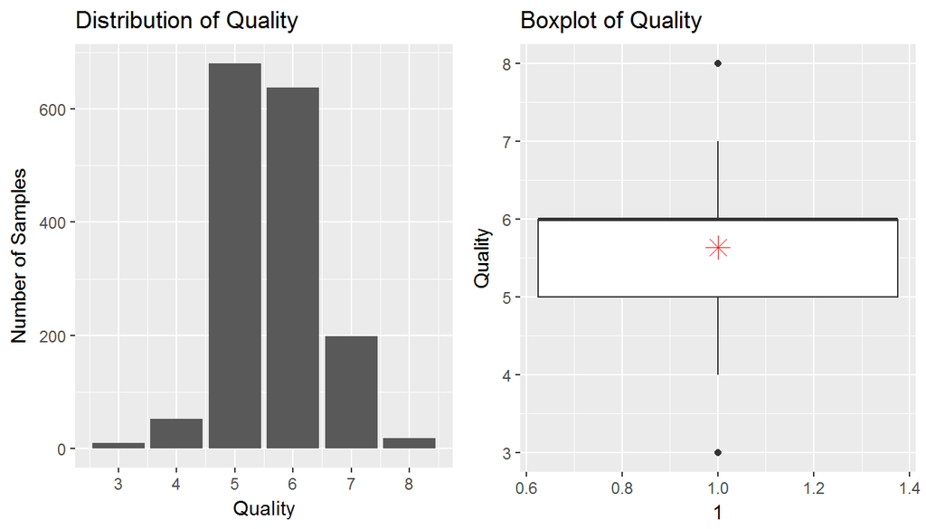

### Description One

Since the objective of this study is to understand the mechanisms of wine’s improvement, the main feature of interest is quality. The distribution of quality shows that most of the wine samples are within the scores 5 or 6. Only a few samples are poor wines (score 3) or excellent wines (score 8), they are classified as outliers. We can see on the boxplot, the median and mean of the quality are near 6 and 5.6, respectively.

As the most wine samples are concentrated within the scores 5 and 6 and the scores 3 and 8 are the outliers of the dataset, the Pearson correlation coefficient of any two variables will not be strong. The best approach to decipt the relation between the quality and any other feature is to use a jitter plot with a boxplot. In the next section, we will do this.

### Plot Two

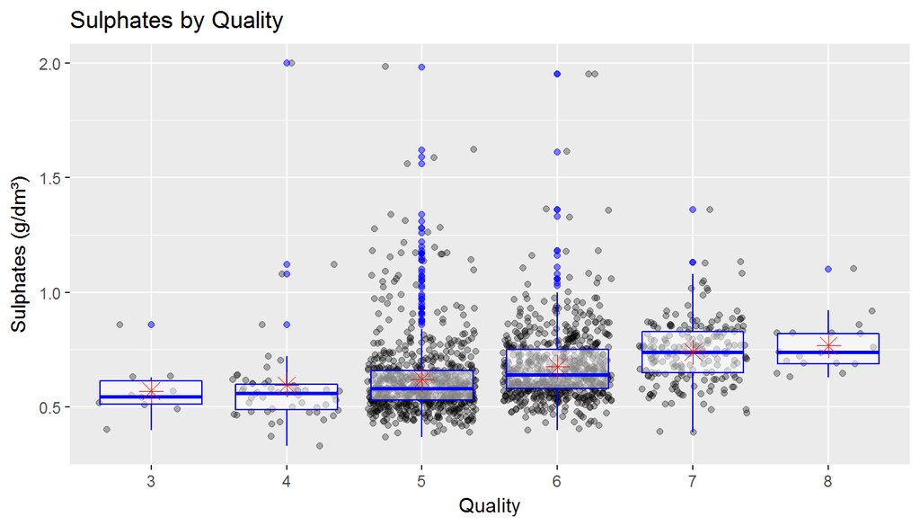

### Description Two

When I plotted the quality against other variables, I was most interested to find plots with great variation between each quality. Quality versus volatile acidity, citric acid, sulphates, density and alcohol gave me interesting results. I was curious to know about how sulphates act in the improvement of wine quality. As sulphate is an additive which acts as an antimicrobial and antioxidant, it prevents the wine grapes from degradation.

The plot sulphates versus quality indicates as the median of sulphates for each quality increases, the wine quality improves. In the next section, we will see how the sulphate indirectly improves the wine quality through citric acid.

### Plot Three

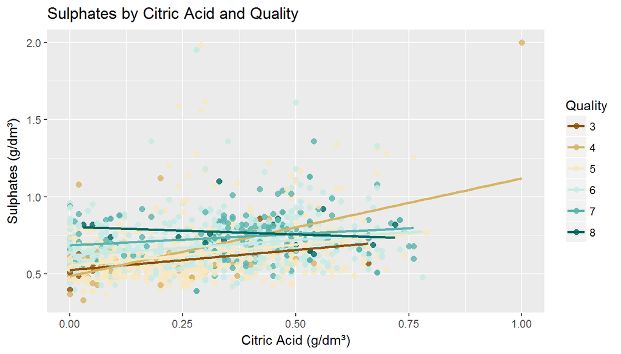

### Description Three

Sulphate is an additive which is added in the beginning of wine’s production to preserve the grapes from oxidation. As citric acid is found in wine grapes, the addition of sulphates would increase the amount of citric acid.

We can see from the plot that sulphates is not strongly correlated with citric acid (Pearson’s coefficient = 0.313), but the increment os sulphates will lead to a higher amount of citric acid consequently improving the wine’s quality.

# Reflection

The Red Wine Quality dataset contains information about 1599 red wine samples across 13 variables. There are 11 input variables based on physicochemical tests and 1 (quality) output variable based on sensory data. I started reading the description of the variables to understand their meanings to later make questions based on their relationships and desirable quantities. And then I analysed each individual variable by plotting their distributions.

As expected, the fixed acidity (most acids involved with wine) correlates positively with citric acid, the fixed acidity correlates negatively with pH and free sulfur dioxide correlates with total sulfur dioxide. Residual sugar and alcohol are moderately correlated with density as described by the author. I didn’t expect to find correlations between density with fixed acidity, citric acid and pH.

I was most interested to find correlations between the quality and some other variable. I found that quality is moderately correlated with alcohol, sulphates, citric acid and volatile acidity. We can better understand their relationships by plotting each physicochemical variable with quality.

With these plots we found that the increase of volatile acidity concentration makes the wine poor. We saw excellent wines have high levels of citric acid. Sulphates helps on the improvement of wine’s quality. Wines with low levels of alcohol are poor and the wine samples become better after the percent alcohol content of 10.5 vol%. .

Later, I plotted the relationship of sulphates with citric acid for each quality and the relationship between the sulphates and volatile acidity for each quality. I found sulphates have an important role in the conservation of wine grapes and consequently in the quality of the wine.

This project was very challenging and very difficult to complete. There were lots of difficulties that I faced throughout the analysis. These difficulties include choosing the best plot which would give me the best understanding of the relation between the quality and each one of the features. I was recommended to use a jitter plot or boxplot instead of histograms. I struggled to implement some codes in R and adjust some plots to make the visualization better. The most difficult task for me was to find relationships between multiples variables.

There are other informations hidden in the dataset to be explored. This analysis is in its initial stage. The study conducted by Cortez *et al*.(2009) goes deeply on the investigation by creating data mining models to predict the most important physicochemical variables for the improvement of wine production.